# Insurance Cross-Sell Model

T3 - Linear Boost

2021-12-07

SMART Problem? Whether a customer would be interested in an additional insurance service like vehicle Insurance is extremely helpful for the company because it can then accordingly plan its communication strategy to reach out to those customers and optimize its business model and revenue. We have following information to assist our analysis: demographics (gender, age, region code type), Vehicles (Vehicle Age, Damage), Policy (Premium, sourcing channel) etc.

## Cross-Sell RAW Data

```
## 'data.frame':    381109 obs. of  12 variables:
##  $ id                  : int  1 2 3 4 5 6 7 8 9 10 ...
##  $ Gender              : chr  "Male" "Male" "Male" "Male" ...
##  $ Age                 : int  44 76 47 21 29 24 23 56 24 32 ...
##  $ Driving_License     : int  1 1 1 1 1 1 1 1 1 1 ...
##  $ Region_Code         : num  28 3 28 11 41 33 11 28 3 6 ...
##  $ Previously_Insured  : int  0 0 0 1 1 0 0 0 1 1 ...
##  $ Vehicle_Age         : chr  "> 2 Years" "1-2 Year" "> 2 Years" "< 1 Year" ...
##  $ Vehicle_Damage      : chr  "Yes" "No" "Yes" "No" ...
##  $ Annual_Premium      : num  40454 33536 38294 28619 27496 ...
##  $ Policy_Sales_Channel: num  26 26 26 152 152 160 152 26 152 152 ...
##  $ Vintage             : int  217 183 27 203 39 176 249 72 28 80 ...
##  $ Response            : int  1 0 1 0 0 0 0 1 0 0 ...
```

## EDA

```r
xkabledply(summary(vehicle))
```

Table

|  | id | Gender | Age | Driving_License | Region_Code | Previously_Insured | Vehicle_Age | Vehicle_Damage | Annual_Premium | Policy_Sales_Channel | Vintage | Response |
| --- | --- | --- | --- | --- | --- | --- | --- | --- | --- | --- | --- | --- |
| X | Min. : 1 | Length:381109 | Min. :20.00 | Min. :0.0000 | Min. : 0.00 | Min. :0.0000 | Length:381109 | Length:381109 | Min. : 2630 | Min. : 1 | Min. : 10.0 | Min. :0.0000 |
| X.1 | 1st Qu.: 95278 | Class :character | 1st Qu.:25.00 | 1st Qu.:1.0000 | 1st Qu.:15.00 | 1st Qu.:0.0000 | Class :character | Class :character | 1st Qu.: 24405 | 1st Qu.: 29 | 1st Qu.: 82.0 | 1st Qu.:0.0000 |
| X.2 | Median :190555 | Mode :character | Median :36.00 | Median :1.0000 | Median :28.00 | Median :0.0000 | Mode :character | Mode :character | Median : 31669 | Median :133 | Median :154.0 | Median :0.0000 |
| X.3 | Mean :190555 | NA | Mean :38.82 | Mean :0.9979 | Mean :26.39 | Mean :0.4582 | NA | NA | Mean : 30564 | Mean :112 | Mean :154.3 | Mean :0.1226 |
| X.4 | 3rd Qu.:285832 | NA | 3rd Qu.:49.00 | 3rd Qu.:1.0000 | 3rd Qu.:35.00 | 3rd Qu.:1.0000 | NA | NA | 3rd Qu.: 39400 | 3rd Qu.:152 | 3rd Qu.:227.0 | 3rd Qu.:0.0000 |
| X.5 | Max. :381109 | NA | Max. :85.00 | Max. :1.0000 | Max. :52.00 | Max. :1.0000 | NA | NA | Max. :540165 | Max. :163 | Max. :299.0 | Max. :1.0000 |

```r
paste0("We will be able to get a idea on the outliers here by the percentiles ( In the Annual_Premium the 3rd quartile is 39400 and the max is 540165 this represents the outliers in this column)")
```

```
## [1] "We will be able to get a idea on the outliers here by the percentiles ( In the Annual_Premium the 3rd quartile is 39400 and the max is 540165 this represents the outliers in this column)"
```

## Response Variable Trend

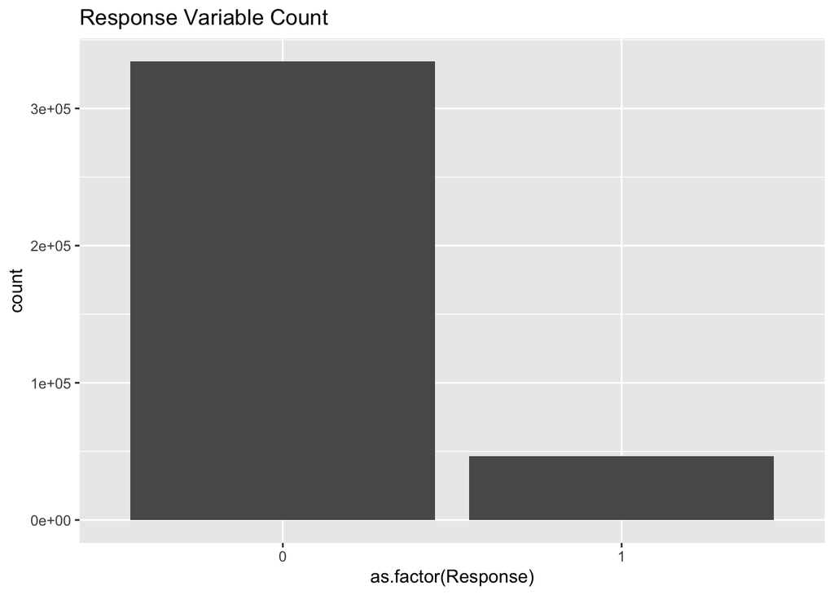

```
##
##         0         1
## 0.8774366 0.1225634
```

[output not shown]

## Variable Conversion

Table

|  | id | Gender | Age | Driving_License | Region_Code | Previously_Insured | Vehicle_Age | Vehicle_Damage | Annual_Premium | Policy_Sales_Channel | Vintage | Response |
| --- | --- | --- | --- | --- | --- | --- | --- | --- | --- | --- | --- | --- |
| id | 1.0000 | -0.0010 | 0.0016 | -0.0006 | -0.0006 | 0.0025 | 0.0009 | -0.0015 | 0.0030 | -0.0028 | -0.0006 | -0.0014 |
| Gender | -0.0010 | 1.0000 | -0.1455 | 0.0184 | -0.0006 | 0.0819 | -0.1604 | -0.0916 | -0.0037 | 0.1112 | 0.0025 | -0.0524 |
| Age | 0.0016 | -0.1455 | 1.0000 | -0.0798 | 0.0426 | -0.2547 | 0.7658 | 0.2675 | 0.0675 | -0.5778 | -0.0013 | 0.1111 |
| Driving_License | -0.0006 | 0.0184 | -0.0798 | 1.0000 | -0.0011 | 0.0150 | -0.0373 | -0.0166 | -0.0119 | 0.0437 | -0.0008 | 0.0102 |
| Region_Code | -0.0006 | -0.0006 | 0.0426 | -0.0011 | 1.0000 | -0.0247 | 0.0438 | 0.0282 | -0.0106 | -0.0424 | -0.0027 | 0.0106 |
| Previously_Insured | 0.0025 | 0.0819 | -0.2547 | 0.0150 | -0.0247 | 1.0000 | -0.3809 | -0.8241 | 0.0043 | 0.2194 | 0.0025 | -0.3412 |
| Vehicle_Age | 0.0009 | -0.1604 | 0.7658 | -0.0373 | 0.0438 | -0.3809 | 1.0000 | 0.3969 | 0.0416 | -0.5507 | -0.0019 | 0.2219 |
| Vehicle_Damage | -0.0015 | -0.0916 | 0.2675 | -0.0166 | 0.0282 | -0.8241 | 0.3969 | 1.0000 | 0.0093 | -0.2244 | -0.0021 | 0.3544 |
| Annual_Premium | 0.0030 | -0.0037 | 0.0675 | -0.0119 | -0.0106 | 0.0043 | 0.0416 | 0.0093 | 1.0000 | -0.1132 | -0.0006 | 0.0226 |
| Policy_Sales_Channel | -0.0028 | 0.1112 | -0.5778 | 0.0437 | -0.0424 | 0.2194 | -0.5507 | -0.2244 | -0.1132 | 1.0000 | 0.0000 | -0.1390 |
| Vintage | -0.0006 | 0.0025 | -0.0013 | -0.0008 | -0.0027 | 0.0025 | -0.0019 | -0.0021 | -0.0006 | 0.0000 | 1.0000 | -0.0011 |
| Response | -0.0014 | -0.0524 | 0.1111 | 0.0102 | 0.0106 | -0.3412 | 0.2219 | 0.3544 | 0.0226 | -0.1390 | -0.0011 | 1.0000 |

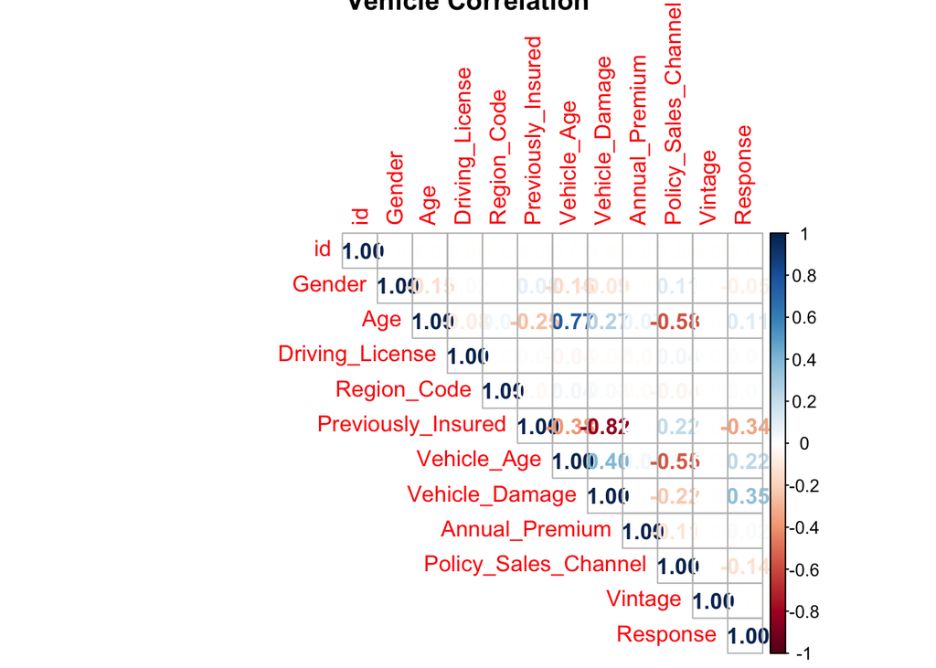

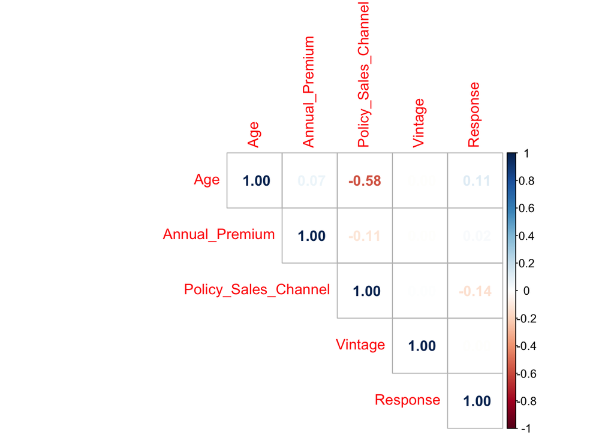

## Feature Selection

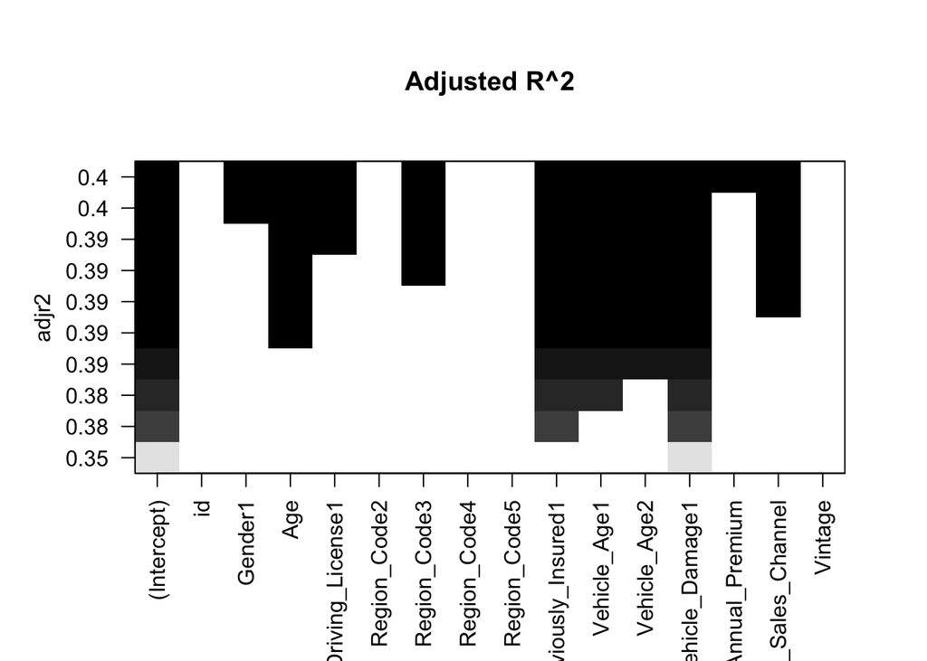

```r
loadPkg("leaps")

regnonlin.forward10 <- regsubsets(Response ~ ., data = vehicle, nvmax = 10, method = "exhaustive")

plot(regnonlin.forward10, scale = "adjr2", main = "Adjusted R^2")
```

```r
summary(regnonlin.forward10)
```

```
## Subset selection object
## Call: regsubsets.formula(Response ~ ., data = vehicle, nvmax = 10,
##     method = "exhaustive")
## 15 Variables  (and intercept)
##                      Forced in Forced out
## id                       FALSE      FALSE
## Gender1                  FALSE      FALSE
## Age                      FALSE      FALSE
## Driving_License1         FALSE      FALSE
## Region_Code2             FALSE      FALSE
## Region_Code3             FALSE      FALSE
## Region_Code4             FALSE      FALSE
## Region_Code5             FALSE      FALSE
## Previously_Insured1      FALSE      FALSE
## Vehicle_Age1             FALSE      FALSE
## Vehicle_Age2             FALSE      FALSE
## Vehicle_Damage1          FALSE      FALSE
## Annual_Premium           FALSE      FALSE
## Policy_Sales_Channel     FALSE      FALSE
## Vintage                  FALSE      FALSE
## 1 subsets of each size up to 10
## Selection Algorithm: exhaustive
##           id  Gender1 Age Driving_License1 Region_Code2 Region_Code3
## 1  ( 1 )  " " " "     " " " "              " "          " "
## 2  ( 1 )  " " " "     " " " "              " "          " "
## 3  ( 1 )  " " " "     " " " "              " "          " "
## 4  ( 1 )  " " " "     " " " "              " "          " "
## 5  ( 1 )  " " " "     "*" " "              " "          " "
## 6  ( 1 )  " " " "     "*" " "              " "          " "
## 7  ( 1 )  " " " "     "*" " "              " "          "*"
## 8  ( 1 )  " " " "     "*" "*"              " "          "*"
## 9  ( 1 )  " " "*"     "*" "*"              " "          "*"
## 10  ( 1 ) " " "*"     "*" "*"              " "          "*"
##           Region_Code4 Region_Code5 Previously_Insured1 Vehicle_Age1
## 1  ( 1 )  " "          " "          " "                 " "
## 2  ( 1 )  " "          " "          "*"                 " "
## 3  ( 1 )  " "          " "          "*"                 "*"
## 4  ( 1 )  " "          " "          "*"                 "*"
## 5  ( 1 )  " "          " "          "*"                 "*"
## 6  ( 1 )  " "          " "          "*"                 "*"
```

[output cut: 11 more lines]

```
## 7  ( 1 )  "*"          "*"             " "            "*"
## 8  ( 1 )  "*"          "*"             " "            "*"
## 9  ( 1 )  "*"          "*"             " "            "*"
## 10  ( 1 ) "*"          "*"             "*"            "*"
##           Vintage
## 1  ( 1 )  " "
## 2  ( 1 )  " "
## 3  ( 1 )  " "
## 4  ( 1 )  " "
## 5  ( 1 )  " "
## 6  ( 1 )  " "
## 7  ( 1 )  " "
## 8  ( 1 )  " "
## 9  ( 1 )  " "
## 10  ( 1 ) " "
```

## Logistic Regression

```
##
## Call:
## glm(formula = Response ~ Vehicle_Age + Vehicle_Damage, family = binomial(link = "logit"),
##     data = vehicle)
##
## Deviance Residuals:
##     Min       1Q   Median       3Q      Max
## -1.6596  -0.3316   0.2698   0.8046   2.7227
##
## Coefficients:
##                  Estimate Std. Error z value Pr(>|z|)
## (Intercept)     -3.681593   0.012939 -284.53   <2e-16 ***
## Vehicle_Age1     0.808325   0.007361  109.82   <2e-16 ***
## Vehicle_Age2     0.932864   0.012656   73.71   <2e-16 ***
## Vehicle_Damage1  3.835026   0.012744  300.93   <2e-16 ***
## ---
## Signif. codes:  0 '***' 0.001 '**' 0.01 '*' 0.05 '.' 0.1 ' ' 1
##
## (Dispersion parameter for binomial family taken to be 1)
##
##     Null deviance: 927151  on 668797  degrees of freedom
## Residual deviance: 634032  on 668794  degrees of freedom
## AIC: 634040
##
## Number of Fisher Scoring iterations: 6
```

All the coefficients are found significant (small p-values). All features have a positive effect on customer response. These are reasonable results and confirms our common beliefs.

We can also easily obtain the growth/decay factors for each variable. Notice that these factors apply to the odds-ratio, not the odds of being accepted. Nonetheless, these growth and decay factors are very useful in our analysis. The factors are the exponential of the coefficients:

Exponential of coefficients of regression model

|  | x |
| --- | --- |
| (Intercept) | 0.0252 |
| Vehicle_Age1 | 2.2441 |
| Vehicle_Age2 | 2.5418 |
| Vehicle_Damage1 | 46.2946 |

From these results, we can say, for example:

- The effect of having a vehicle for 1 to 2 years, compared to less than 1 year, is boosting by a factor of 2.244, for the log(odds-ratio). Any factor less than 1 represents a negative effect.
- The effect of having a vehicle for more than 2 years, compared to less than 1 year, is boosting even more, by a factor of 2.542, again, for the log(odds-ratio).
- Customers with vehicle damage are likely to respond more, by a factor of 46.29, again, for the log(odds-ratio).

**Confusion Matrix**

Confusion matrix from Logit Model

|  | Predicted 0 | Predicted 1 | Total |
| --- | --- | --- | --- |
| Actual 0 | 187714 | 146685 | 334399 |
| Actual 1 | 6973 | 327426 | 334399 |
| Total | 194687 | 474111 | 668798 |

[output not shown]

**Receiver-Operator-Characteristic (ROC) curve and Area-Under-Curve (AUC)**

```
## Area under the curve: 0.8019
```

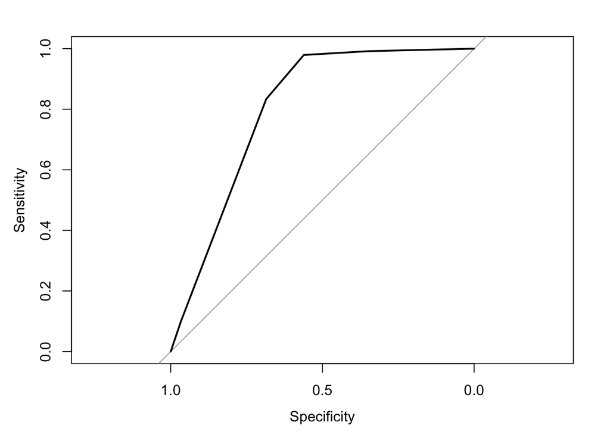

```
## [1] "Area under the curve is greater than 80% which indicates that the model is a good fit."
```

**DECISION TREES Confusion Matrix**

Response Classification Trees summary with varying MaxDepth

| Depth | Accuracy | Sensitivity | Specificity | Pos.Pred.Value | Neg.Pred.Value | Precision | Recall | F1 | Prevalence | Detection.Rate | Detection.Prevalence | Balanced.Accuracy |
| --- | --- | --- | --- | --- | --- | --- | --- | --- | --- | --- | --- | --- |
| 2 | 0.7702 | 0.5613 | 0.9791 | 0.9642 | 0.6906 | 0.9642 | 0.5613 | 0.7096 | 0.5 | 0.2807 | 0.2911 | 0.7702 |
| 3 | 0.7702 | 0.5613 | 0.9791 | 0.9642 | 0.6906 | 0.9642 | 0.5613 | 0.7096 | 0.5 | 0.2807 | 0.2911 | 0.7702 |
| 4 | 0.7702 | 0.5613 | 0.9791 | 0.9642 | 0.6906 | 0.9642 | 0.5613 | 0.7096 | 0.5 | 0.2807 | 0.2911 | 0.7702 |
| 5 | 0.7702 | 0.5613 | 0.9791 | 0.9642 | 0.6906 | 0.9642 | 0.5613 | 0.7096 | 0.5 | 0.2807 | 0.2911 | 0.7702 |
| 6 | 0.7702 | 0.5613 | 0.9791 | 0.9642 | 0.6906 | 0.9642 | 0.5613 | 0.7096 | 0.5 | 0.2807 | 0.2911 | 0.7702 |

**DECISION TREES Tree Plot**

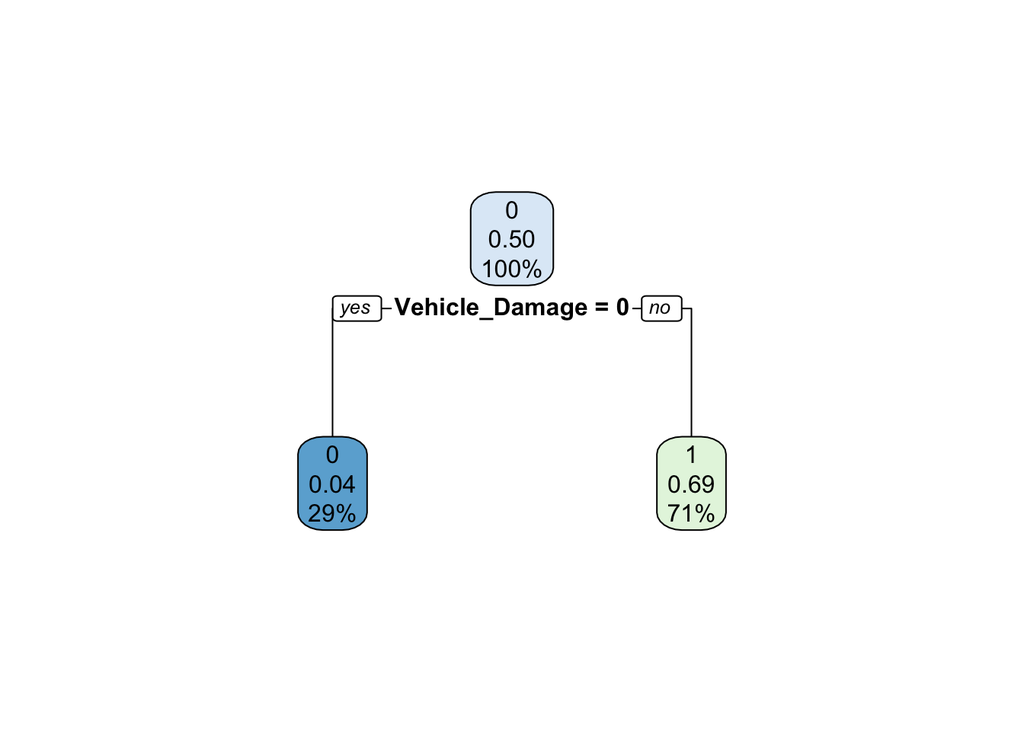

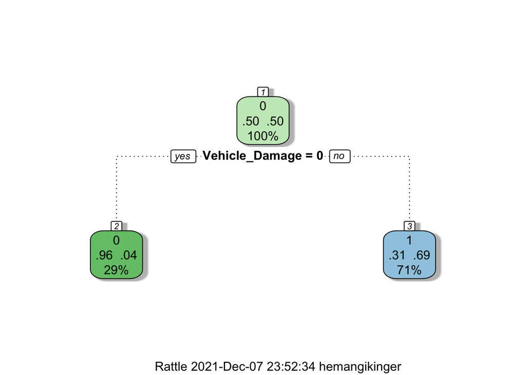

## Extreme Gradient Boosting

[output not shown]

```
## ##### xgb.Booster
## raw: 32.9 Mb
## call:
##   xgb.train(params = params, data = xgb.train, nrounds = 500, watchlist = list(val1 = xgb.train,
##     val2 = xgb.test), verbose = 0, early_stopping_rounds = 10,
##     nthreads = 1)
## params (as set within xgb.train):
##   booster = "gbtree", eta = "0.1", max_depth = "10", gamma = "3", subsample = "0.75", colsample_bytree = "0.75", objective = "multi:softprob", eval_metric = "merror", num_class = "2", nthreads = "1", validate_parameters = "TRUE"
## xgb.attributes:
##   best_iteration, best_msg, best_ntreelimit, best_score, niter
## callbacks:
##   cb.evaluation.log()
##   cb.early.stop(stopping_rounds = early_stopping_rounds, maximize = maximize,
##     verbose = verbose)
## # of features: 11
## niter: 500
## best_iteration : 500
## best_ntreelimit : 500
## best_score : 0.15186
## best_msg : [500] val1-merror:0.131217    val2-merror:0.151860
## nfeatures : 11
## evaluation_log:
##     iter val1_merror val2_merror
##        1    0.194239    0.198594
##        2    0.194169    0.197871
## ---
##      499    0.131249    0.151878
##      500    0.131217    0.151860
```

```
## [1] "Final Accuracy = 84.81%"
```

**XGBoost Confusion Matrix**

Confusion matrix from XGBoost Model

|  | 0 | 1 |
| --- | --- | --- |
| 0 | 60520 | 2457 |
| 1 | 22934 | 81289 |

```
## [1] "Accuracy of the model is 84.8%."
```

**XGBoost Receiver-Operator-Characteristic (ROC) curve and Area-Under-Curve (AUC)**

```
## Area under the curve: 0.8479
```

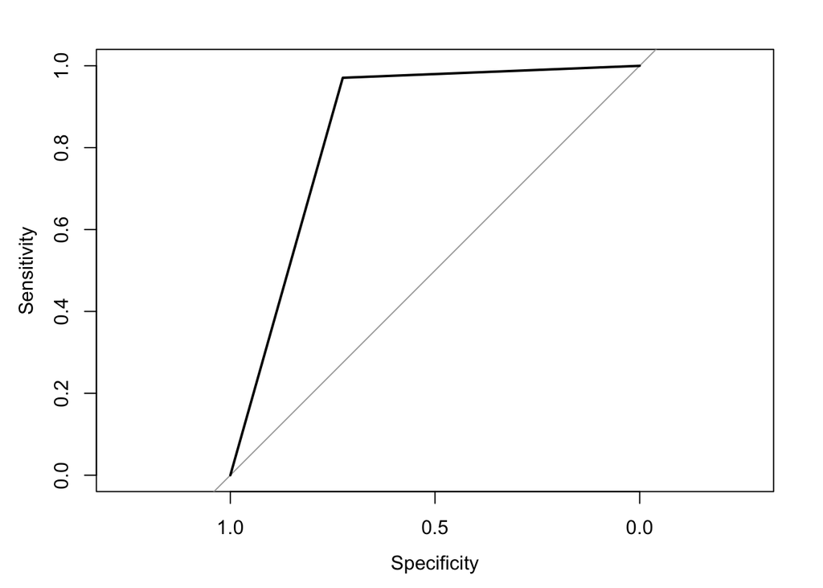

```
## [1] "Area under the curve is greater than 80% which indicates that the model is a good fit."
```